# BTR Results Overview

2024-08-01 11:32:04.152863

# Emissions

## Energy CO2 Emissions by Sector

### Sector

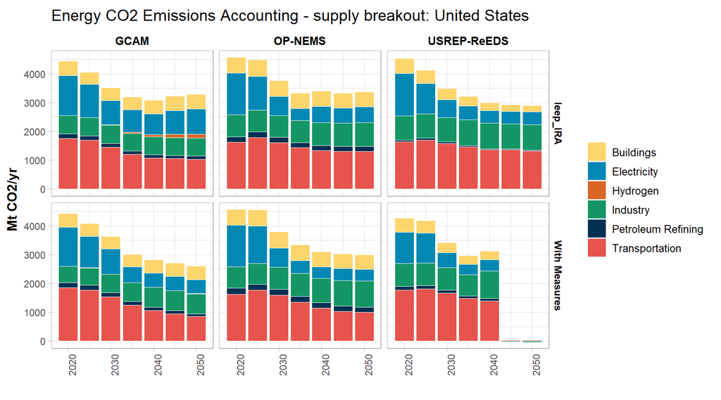

### Model

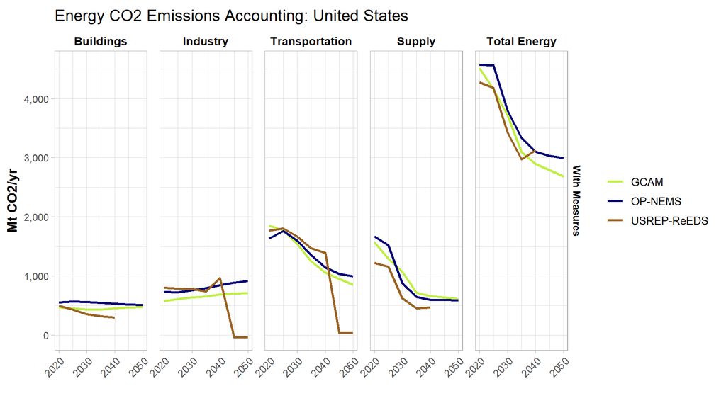

## Energy CO2 Emissions by Fuel

### Fuel

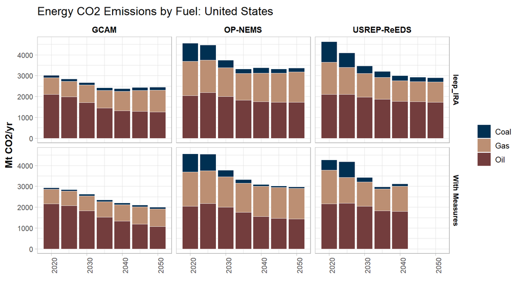

### Model

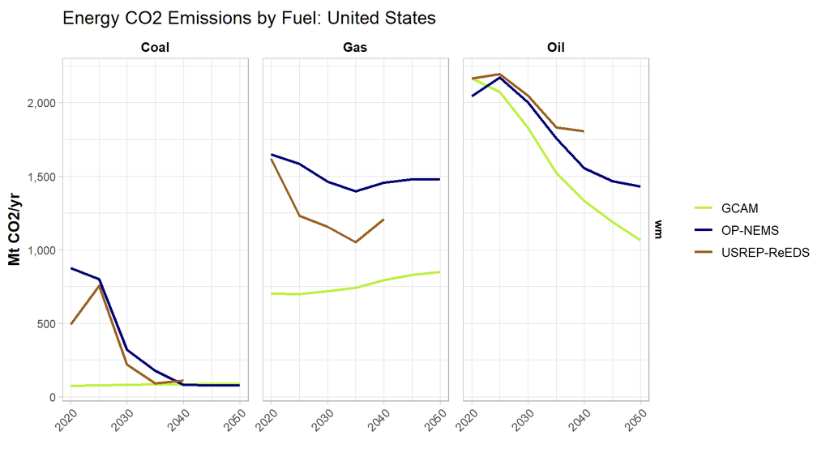

# Energy Consumption

## Final Energy

### Fuel

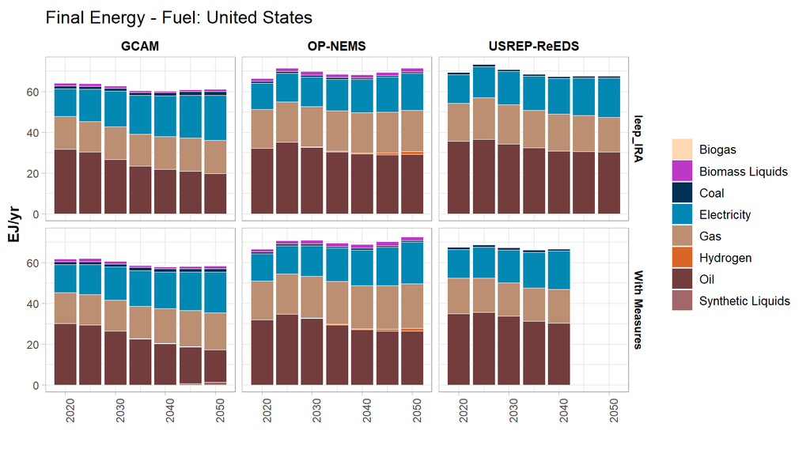

### Fuel by Model

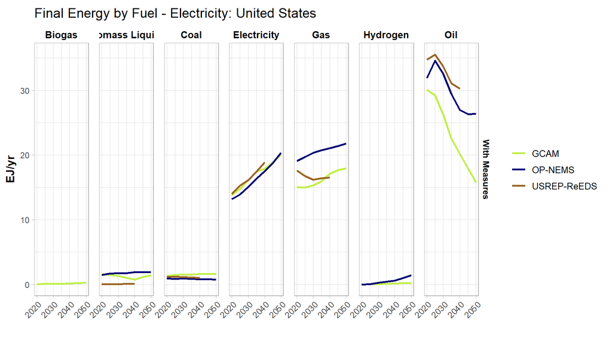

### Fuel by Model - Zoom

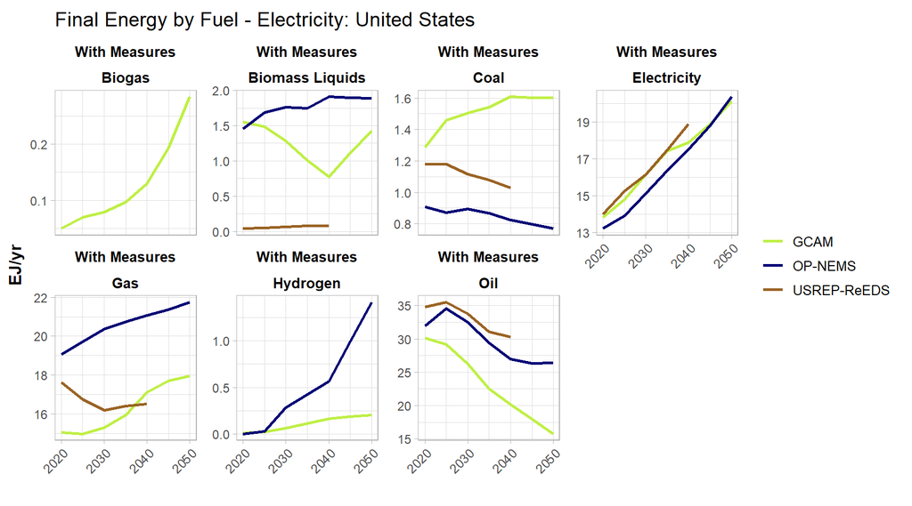

Energy consumption is estimated to change from 2020 to 2040:

- GCAM: -6%
- OP-NEMS: 3%
- USREP-ReEDS: -1%

By fuel-type, energy consumption is estimated to change from 2020 to 2040:

- Coal:
  - GCAM: 25%
  - OP-NEMS: -9%
  - USREP-ReEDS: -13%
- Electricity:
  - GCAM: 30%
  - OP-NEMS: 32%
  - USREP-ReEDS: 35%
- Gas:
  - GCAM: 14%
  - OP-NEMS: 10%
  - USREP-ReEDS: -6%
- Oil:
  - GCAM: -33%
  - OP-NEMS: -15%
  - USREP-ReEDS: -13%

### Sector

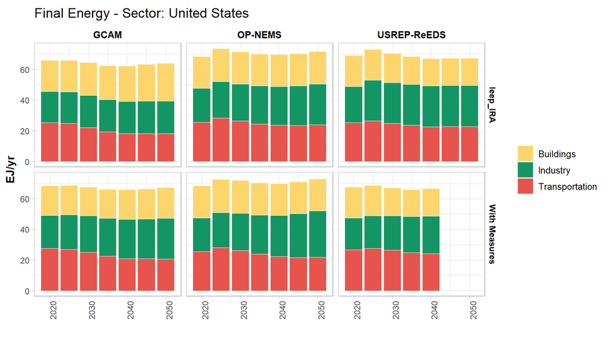

By sector, energy consumption is estimated to change from 2020 to 2040:

- Buildings:
  - GCAM: -2%
  - OP-NEMS: -1%
  - USREP-ReEDS: -10%
- Industry:
  - GCAM: 20%
  - OP-NEMS: 22%
  - USREP-ReEDS: 17%
- Transportation:
  - GCAM: -24%
  - OP-NEMS: -13%
  - USREP-ReEDS: -9%

### Sector by Model

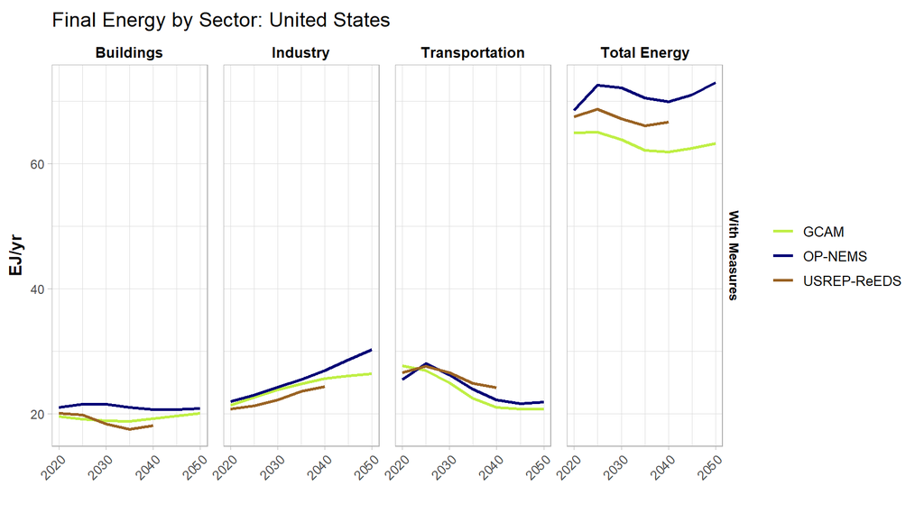

## Final Energy by Sector

### Buildings

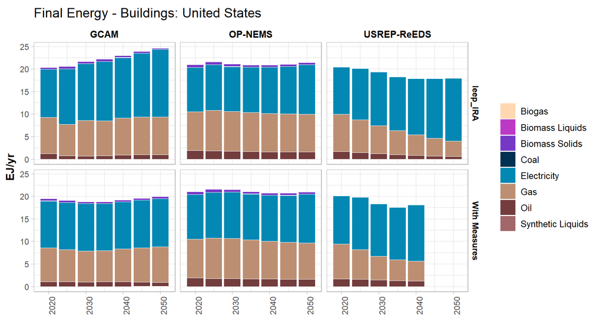

### Buildings by Model

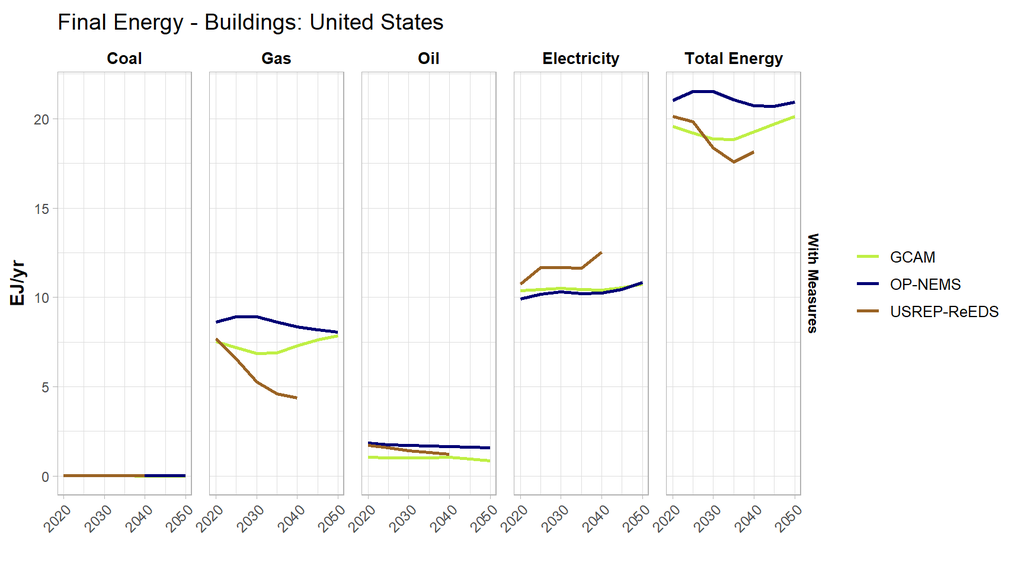

### Industry

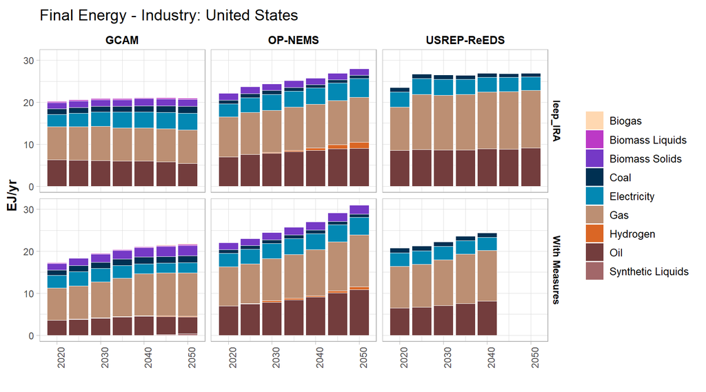

### Industry by Model

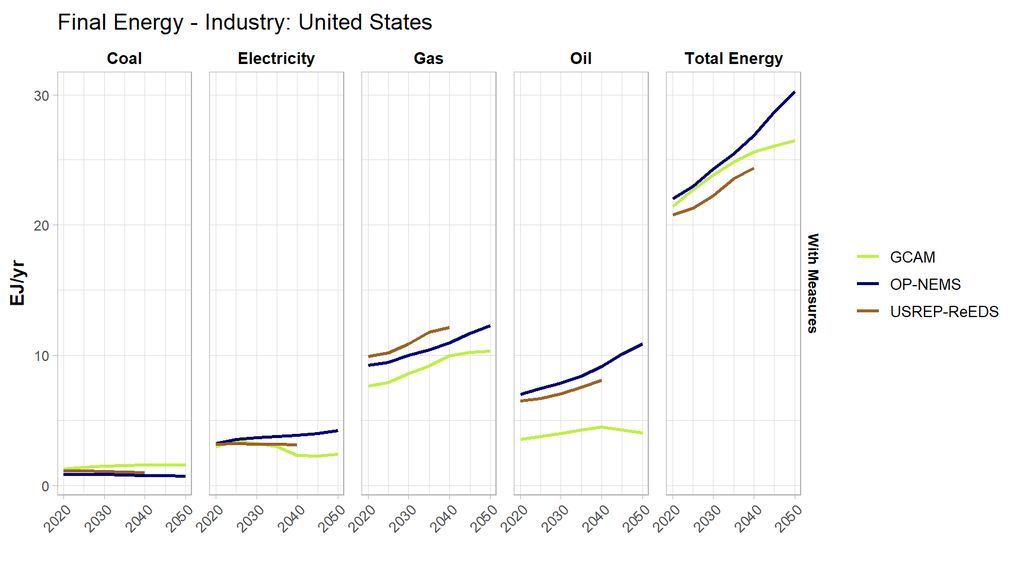

### Transportation

TODO: Add facets vehicle type sales share/stock share, tabs freight/passenger

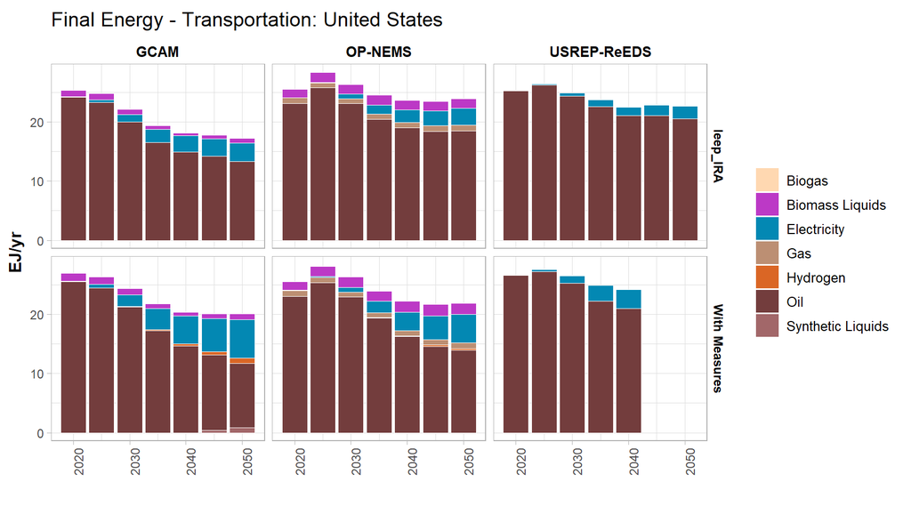

### Transportation by Model

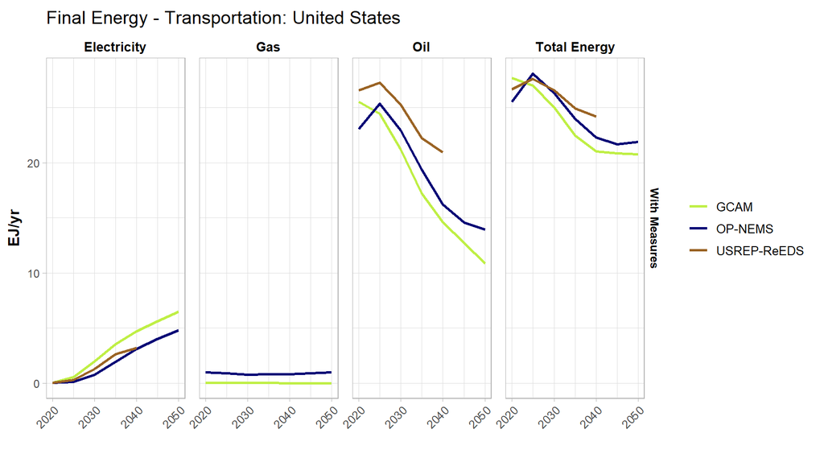

### Buildings, Residential

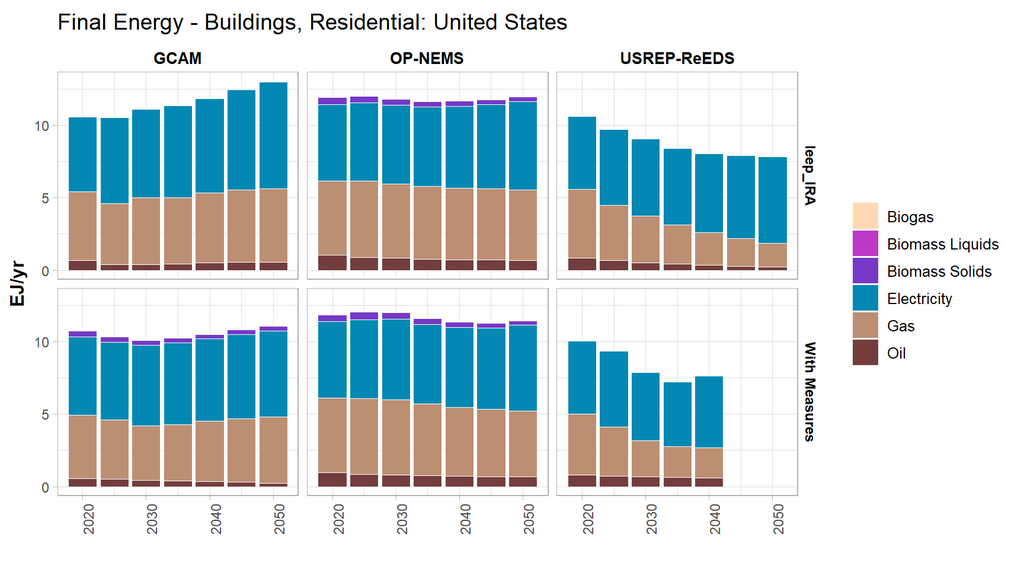

### Buildings, Residential by Model

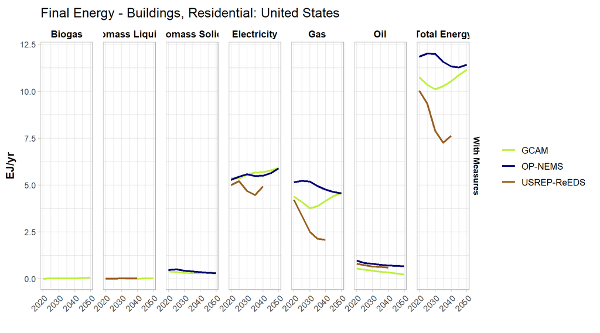

### Buildings, Commercial

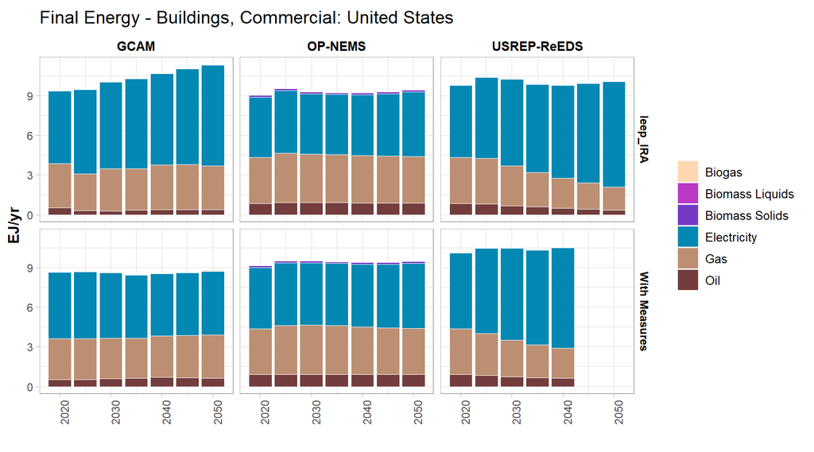

### Buildings, Commercial by Model

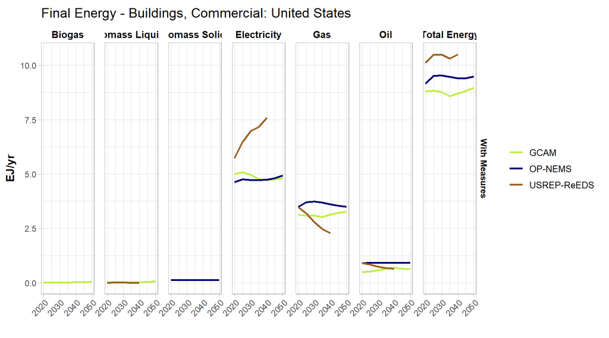

## Percent Electricity

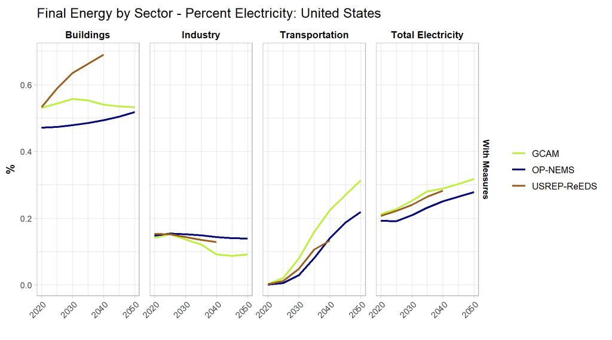

# Energy Production

## Secondary Energy

### Fuel

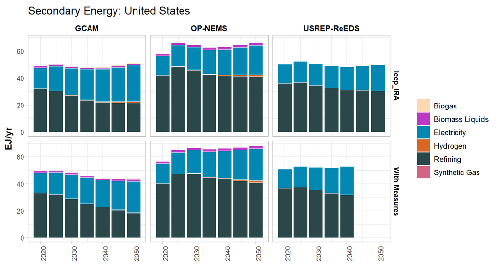

### Model

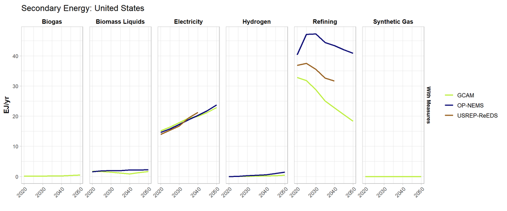

### Model - Zoom

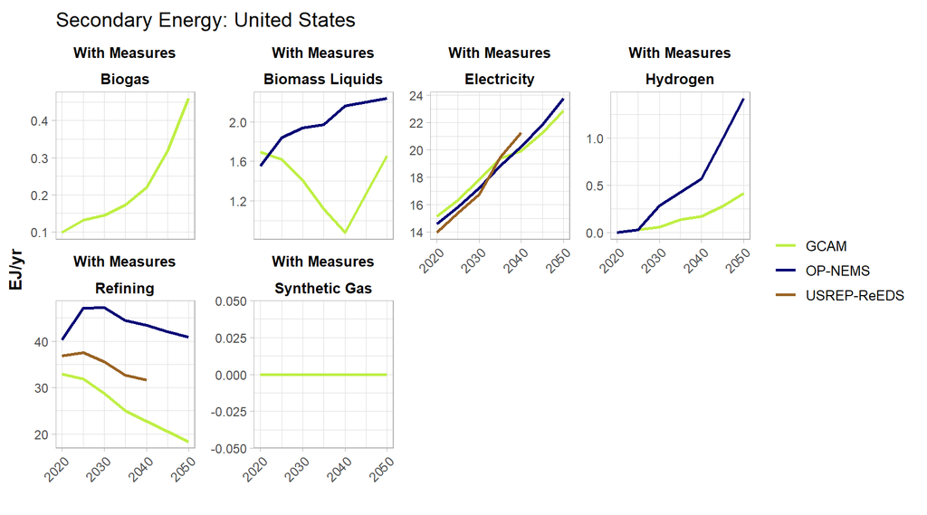

## Electricity Production

### Generation

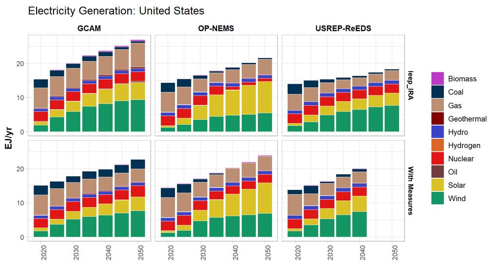

### Generation by Model

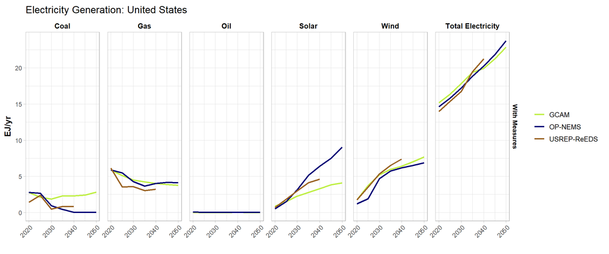

### Generation by Model - Zoom

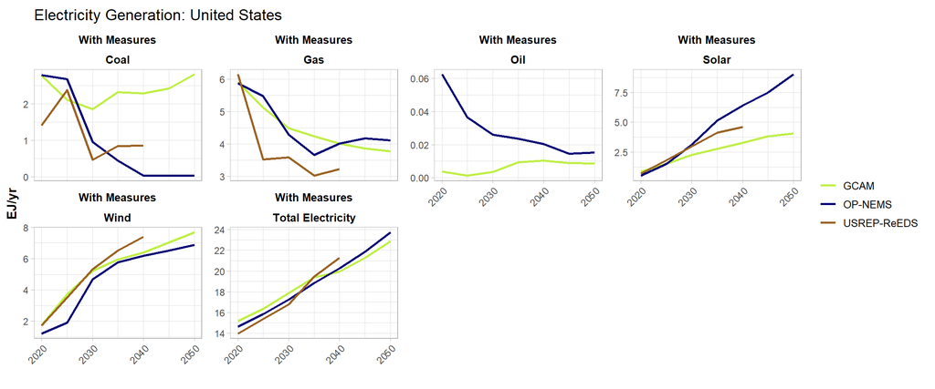

### Capacity

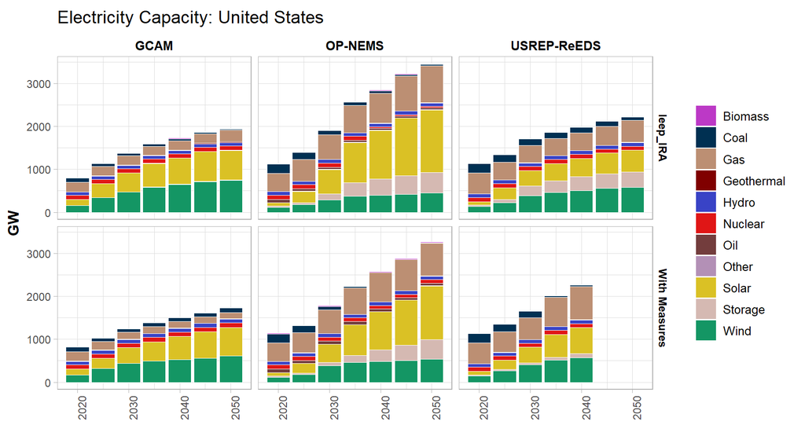

Electricity capacity is estimated to increase from 2020 to 2040:

- GCAM: 83%
- OP-NEMS: 126%
- USREP-ReEDS: 100%

By technology, electricity capacity is estimated to change from 2020 to 2040:

- Coal:
  - GCAM: -15%
  - OP-NEMS: -97%
  - USREP-ReEDS: -84%
- Gas:
  - GCAM: -32%
  - OP-NEMS: 58%
  - USREP-ReEDS: 59%
- Oil:
  - GCAM: 173%
  - OP-NEMS: -24%
- Solar:
  - GCAM: 279%
  - OP-NEMS: 981%
  - USREP-ReEDS: 626%
- Storage:
  - OP-NEMS: 1015%
  - USREP-ReEDS: 293%
- Wind:
  - GCAM: 223%
  - OP-NEMS: 311%
  - USREP-ReEDS: 295%

### Capacity by Model

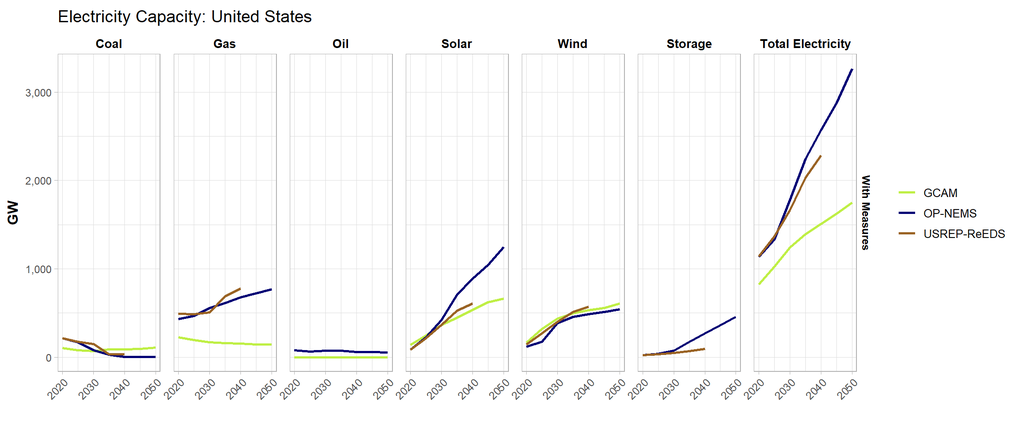

### Capacity by Model - Zoom

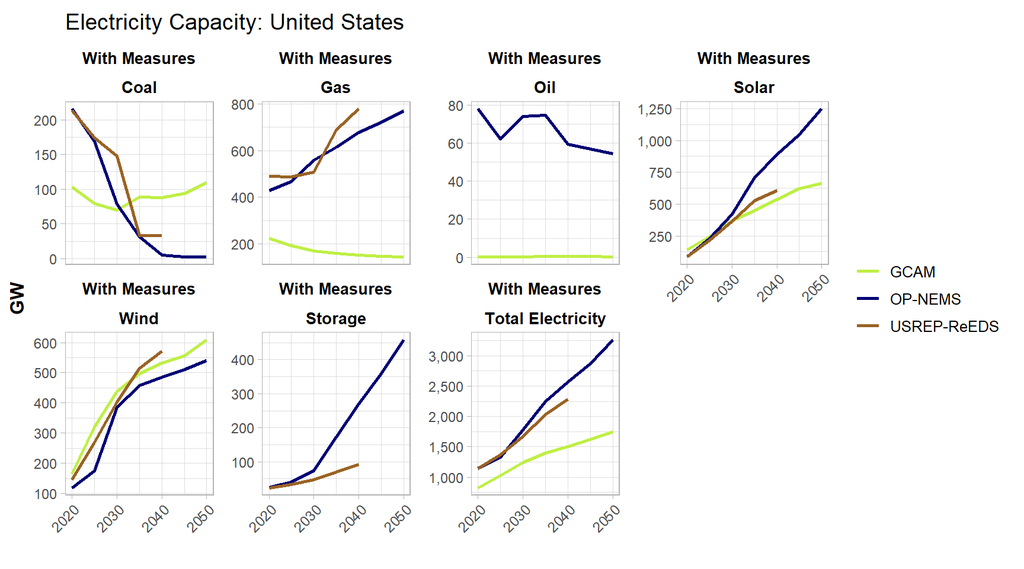

## Electricity Production - Combustion

### Generation

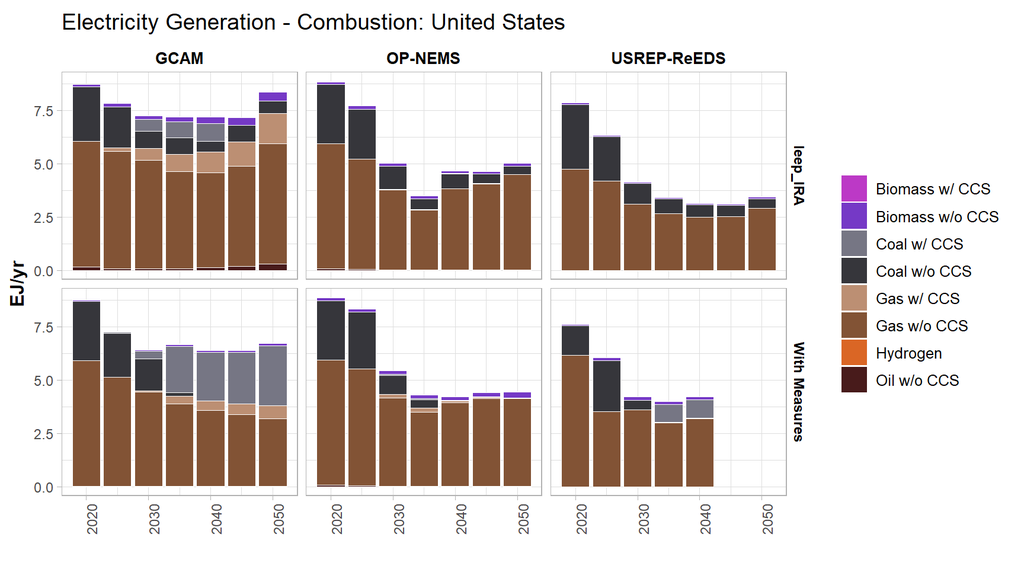

### Generation by Model

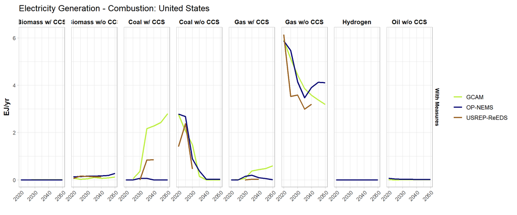

### Generation by Model - Zoom

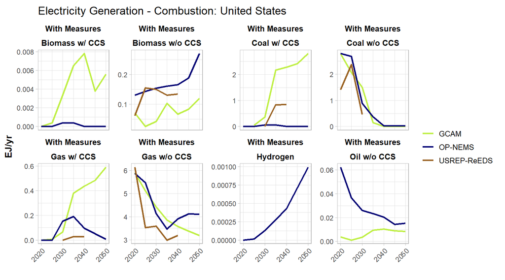